# Cabbages

Kelly Patrizio!

September 10, 2020

# Introduction

### Is there a difference in average VitC between c39 and c52 cultivation methods?

# Results

## Descriptive Results

### Graphical Descriptive Results

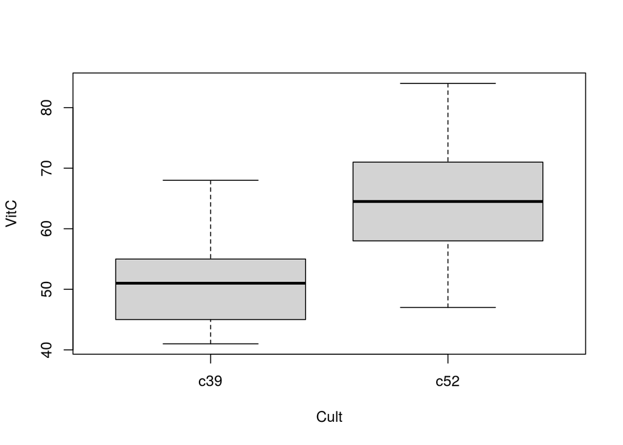

```r
boxplot(VitC ~ Cult,data=veggy)
```

### Numerical Descriptive Results

```r
favstats(VitC ~ Cult,data=veggy)
```

| Cult | min | Q1 | median | Q3 | max | mean | sd | n | missing |
| --- | --- | --- | --- | --- | --- | --- | --- | --- | --- |
| c39 | 41 | 46 | 51.0 | 54.75 | 68 | 51.5 | 7.123298 | 30 | 0 |
| c52 | 47 | 58 | 64.5 | 70.75 | 84 | 64.4 | 8.455156 | 30 | 0 |

The question is there a difference in average VitC due to the cultivation between c39 and c52 cultivation methods?

$H_0$: There is no difference in VitC content due to cultivation.

$H_A$:There is a difference in VitC due to cultivation.

```r
t.test(VitC ~ Cult,data=veggy)
```

```
##
##  Welch Two Sample t-test
##
## data:  VitC by Cult
## t = -6.3909, df = 56.376, p-value = 3.405e-08
## alternative hypothesis: true difference in means is not equal to 0
## 95 percent confidence interval:
##  -16.94296  -8.85704
## sample estimates:
## mean in group c39 mean in group c52
##              51.5              64.4
```

# Discussion and Conclusion

The difference in VitC content, according to the box plot, is that C52 has a higher content than C39 when using cultivation methods. According to the numeric summary, C52 has approximately 13 more units than C39 using the cultivation method.  
Lastly, according to the t-test, the Pvalue is 0.00000003 which is smaller than 0.05 which makes the null hypothesis unlikely; Which means the alternative is likely and we reject the null hypothesis! In conclusion we find there is a difference in vitamin C39 and C52 content based on the cultivation method.